# 1 Quão previsivel você é?

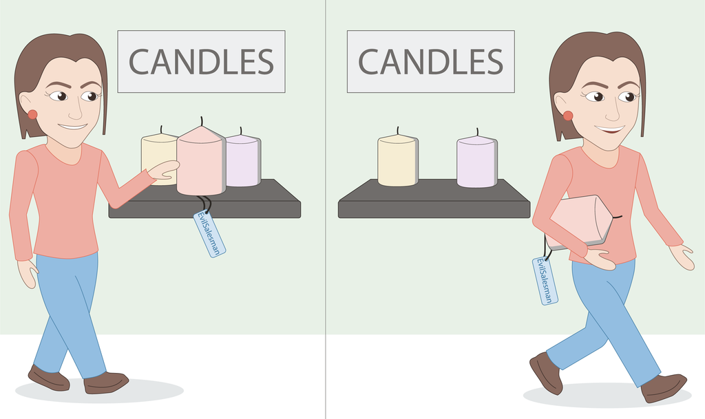

Figure 1.1: Será que o posicionamento de um produto pode influenciar o consumidor?

## 1.1 Objetivo

Introduzir os visitantes da mostra ao conceito de efeito do palco central, como ele é utilizado e como podemos representá-lo de forma probabilística.

## 1.2 Construção

São necessários para a execução desse experimento:

1. Um dado
2. Papel e caneta para anotar os resultados. Após um número significativo de repetições, esses dados se tornaram um registro das probabilidades empíricas associadas ao experimento.

## 1.3 Execução

Primeiramente pergunta-se ao visitante qual é o valor que ele acredita que vai sair quando o dado for lançado. Logo após o palpite ser anotado, o dado é lançado e seu resultado também é anotado. Por fim, a teoria por trás do experimento deve ser explicada.

Vale ressaltar que ocultar os palpites anteriores é uma boa prática para evitar influenciar o participante.

## 1.4 Teoria

### 1.4.1 O efeito do palco central

O efeito do palco central, *center stage effect* em inglês, descreve a tendência das pessoas em escolher opções que se localizam no meio dentre um conjunto de possíveis escolhas.

Num dos primeiros estudos a documentar este fenómeno, pediu-se às pessoas que escolhessem um número entre 1 e 12. 58,9% dos participantes escolheram os números 5, 6, 7 e 8, o que representa 33% das escolhas possíveis. O efeito foi ainda mais nítido quando foi oferecido aos participantes um prêmio em dinheiro por palpites corretos: 76% escolheram um dos quatro números do meio.

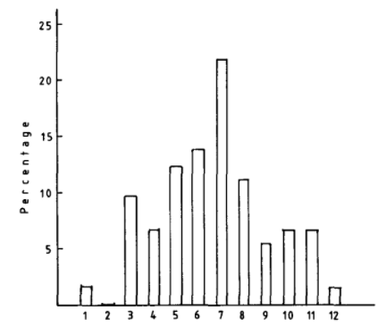

Figure 1.2: K. Teigen (1983).

### 1.4.2 Distribuições de probabilidade

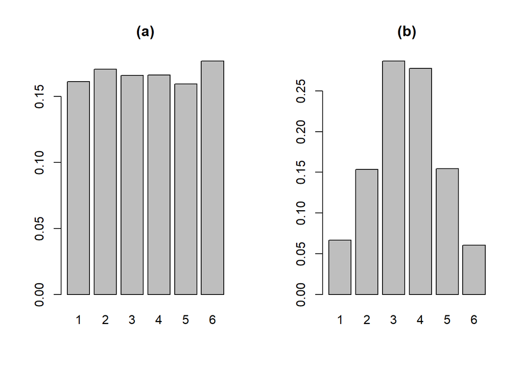

Como o dado é honesto, toda face tem a mesma probabilidade de sair após um lançamento. Portanto, é natural assumir que, na hora da escolha, nenhuma face seja favorecida em relação às outras. Assumindo isso como verdade, podemos dizer que a probabilidade de escolha é igual para todas as faces. O gráfico de frequência relativa para essa distribuição é composto por barras de pesos parecidos, representado pelo exemplo (a).

> É importante ressaltar que qualquer adição ou mudança na explicação da teoria para torná-la mais clara e acessível aos participantes é bem-vinda. Diversos são os visitantes da mostra e a explicação que é óbvia para alguns pode ser confusa para outros.

## 1.5 Aplicação prática

Empresas, por exemplo, utilizam o fenômeno do palco central para “influenciar” seus consumidores a optarem por determinado item, empregando estratégias que colocam em destaque o produto desejado. Ao direcionar a atenção do consumidor para um produto específico, as empresas buscam criar uma percepção de importância e superioridade em relação às alternativas disponíveis.

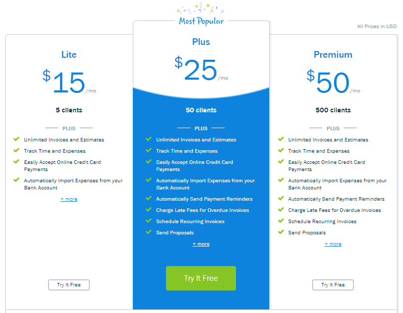

Figure 1.3: Exemplo de propaganda

## 1.6 Referências e leituras complementares

**Paul Meyer**. Probabilidade - Aplicações à Estatística, 2ª ed. capítulos 4.7. “Variáveis Aleatórias Uniformemente Distribuídas” e 4.3. “A Distribuição Binomial”.

**Kent Hendricks**. “The center stage effect: this is why you choose the product in the middle (even if it’s bad)”, disponível em: https://kenthendricks.com/center-stage-effect/

Figure 1.1 - Disponível em https://cognitivebias.io/bias/center-stage-effect

Figure 1.2, Figure 1.3 - Disponível em https://kenthendricks.com/center-stage-effect/